# Non-linear modeling

John Brandt

11/24/2017

# Overview

In order to model tree height based upon diameter at breast height (DBH), I try a square root transformed generalized least squares model (GLS), non linear least squares (NLS) with set starting values and with iterative brute force modeling, as well as natural cubic splines transformation of GLS.

I find that the GLS with a natural cubic splines transformation does the best job at modeling the data.

# Read in Data

```r
require(ggplot2)
require(lme4)
require(nlme)
require(nls2)
require(splines)

pa <- read.table("pa_roak.dat.txt", skip=9,
                                   col.names=c("dbh.in","vol.ft3","ht.ft"))
```

# Metric conversions

```r
pa$dbh.cm <- pa$dbh.in * 2.54
pa$ht.m <- pa$ht.ft * 0.3048
pa$ba.ft2 <- pi*(pa$dbh.in/2/12)^2
pa$ba.m2 <- pi*(pa$dbh.cm/100/2)^2
pa$D2H.ft3 <- (pa$dbh.in/12)^2  * pa$ht.ft
pa$D2H.m3  <- (pa$dbh.cm/100)^2 * pa$ht.m

pa$vol.m3 <- pa$vol.ft3 * (.3048^3)

attach(pa)
```

# Data Exploration

## Preview data structure

```r
round(head(pa), 3)
```

```
##   dbh.in vol.ft3 ht.ft dbh.cm   ht.m ba.ft2 ba.m2 D2H.ft3 D2H.m3 vol.m3
## 1    9.3    10.7  39.0 23.622 11.887  0.472 0.044  23.424  0.663  0.303
## 2   14.8    35.3  51.0 37.592 15.545  1.195 0.111  77.577  2.197  1.000
## 3    6.3     4.6  33.6 16.002 10.241  0.216 0.020   9.261  0.262  0.130
## 4   13.1    25.5  54.0 33.274 16.459  0.936 0.087  64.354  1.822  0.722
## 5   10.2    15.4  53.0 25.908 16.154  0.567 0.053  38.292  1.084  0.436
## 6    9.6    14.1  51.9 24.384 15.819  0.503 0.047  33.216  0.941  0.399
```

## Graph DBH vs Height

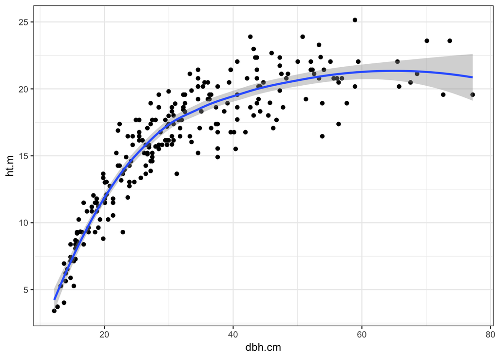

```r
plot1 <- ggplot(data=pa, aes(x=dbh.cm, y= ht.m))+
  geom_point()+
  geom_smooth()+
  theme_bw()

print(plot1)
```

# Generalized Least Squares

Begin by trying a generalized least squares linear model with a 1/sqrt transformed predictor variable.

AIC = 1410

```r
gls1 <- gls(ht.m ~ 1/sqrt(dbh.cm))
AIC(gls1)
```

```
## [1] 1410.675
```

# Nonlinear least squares - random starting values

Trying nonlinear least squares modeling in the form of b0 + b1 * dbh ^ b2

Begin by selecting random starting values (500,500, -0.5)

The resulting model has an AIC of 915 and results in the following variables:

- b0 = 24.85
- b1 = -405
- b2 = -1.16

AIC = 915

```r
nls_1 <- gnls(ht.m~b0 + b1*dbh.cm^b2, start=list(b0=500, b1=500, b2=-0.5))

AIC(nls_1)
```

```
## [1] 915.8467
```

# NLS - brute force method

Next, we try the brute force method where we create a starting grid and then iteratively build all possible models and select the best one.

## Brute force 1

Results:

- b0 = 24
- b1 = -565
- b2 = -1.3

```r
starting.grid <- expand.grid(list(b0=seq(15,45, by=1),
                                 b1=seq(-600,-300, by=5),
                                 b2=seq(-2,0, by=0.1)))

nls_2 <- nls2(ht.m~b0 + b1*dbh.cm^b2, start=starting.grid,
              algorithm="brute-force")
```

```r
AIC(nls_2)
```

```
## [1] 917.7198
```

## Brute force 2

Same as above but with more granular starting grid.

Results:

- b0 = 24.8
- b1 = -413
- b2 = -1.17

```r
starting.grid.2 = expand.grid(list(b0=seq(23,26, by=0.1),
                                   b1=seq(-550,-380, by=1),
                                   b2=seq(-1.27,-1.1, by=0.01)))

nls_3 <- nls2(ht.m~b0 + b1*dbh.cm^b2, start=starting.grid.2,
              algorithm="brute-force")

AIC(nls_3)
```

```
## [1] 915.8653
```

### Residuals plot

Residuals plot show heteroskedasticity of residuals, with a higher variance as yhat increases.

We will choose the best model and then deal with heteroskedasticity.

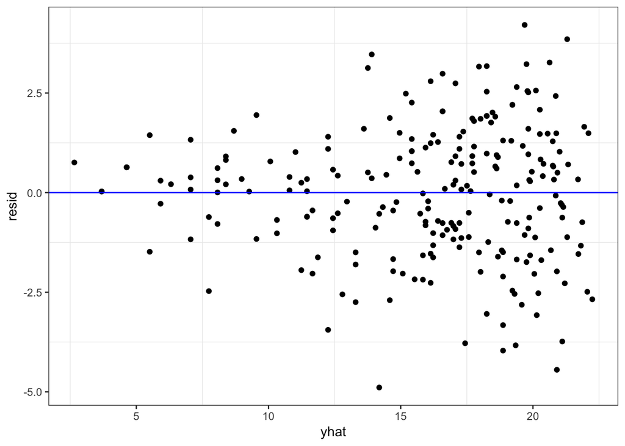

```r
resid <- resid(nls_3)
yhat <- fitted(nls_3)
residplot <- ggplot(data=pa, aes(x=yhat, y=resid))+
  geom_point()+
  geom_hline(yintercept=0, color = "blue")+
  theme_bw()+
  theme(panel.grid.major=element_blank())
print(residplot)
```

### Confirm model selection with NLS

```r
nls_6 <- gnls(ht.m~b0 + b1*dbh.cm^b2, start=list(b0=25, b1=-403, b2=-1.16))

coef(nls_6)
```

```
##         b0         b1         b2
##   24.84557 -405.22059   -1.16198
```

### Predicted vs observed data

The gnls function and the nls2 functions didn’t work because the model it selected doesn’t even overlap the points that it is built upon.

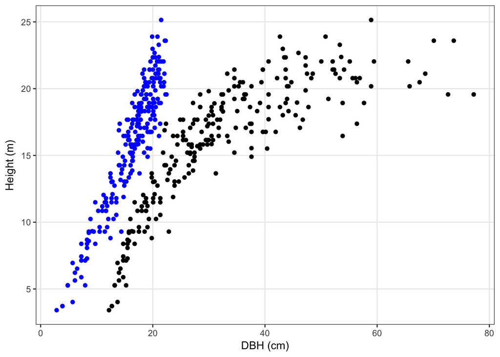

```r
plot2 <- ggplot(data=pa, aes(x=dbh.cm, y=ht.m))+
  geom_point()+
  geom_point(aes(25-(413*dbh.cm^-1.17)), color="blue")+
  theme_bw()+
  theme(panel.grid.minor=element_blank())+
  xlab("DBH (cm)")+
  ylab("Height (m)")
print(plot2)
```

# Natural cubic splines model

## Function

The following equation is Eq 2.25 in Harrell p. 20

```r
natural.spline.comp<-function(X,t,j) {
  k<-length(t)
  pmax(0,X-t[j])^3-pmax(0,X-t[k-1])^3*(t[k]-t[j])/(t[k]-t[k-1])+
    pmax(0,X-t[k])^3*(t[k-1]-t[j])/(t[k]-t[k-1])
}
```

## Knot Selection

To select proper knot placement, I begin with 0.10, 0.50, and 0.90, and then tweak the placements and choose the placement that results in the lowest AIC score.

```r
knots <- quantile(dbh.cm, probs=c(0.10,0.50,0.90), na.rm=TRUE)
knots_2 <- quantile(dbh.cm, probs=c(0.10,0.30,0.90), na.rm=TRUE)
knots_3 <- quantile(dbh.cm, probs=c(0.10,0.35,0.80), na.rm=TRUE)
knots_4 <- quantile(dbh.cm, probs=c(0.10,0.35,0.75), na.rm=TRUE)
knots_5 <- quantile(dbh.cm, probs=c(0.05,0.35,0.75), na.rm=TRUE)

splinepoints <- natural.spline.comp(dbh.cm, knots, 1)
splinepoints_2 <- natural.spline.comp(dbh.cm, knots_2, 1)
splinepoints_3 <- natural.spline.comp(dbh.cm, knots_3, 1)
splinepoints_4 <- natural.spline.comp(dbh.cm, knots_4, 1)
splinepoints_5 <- natural.spline.comp(dbh.cm, knots_5, 1)

gls_knot_1 <- gls(ht.m ~ dbh.cm + splinepoints)
gls_knot_2 <- gls(ht.m ~ dbh.cm + splinepoints_2)
gls_knot_3 <- gls(ht.m ~ dbh.cm + splinepoints_3)
gls_knot_4 <- gls(ht.m ~ dbh.cm + splinepoints_4)
gls_knot_5 <- gls(ht.m ~ dbh.cm + splinepoints_5)

AIC(gls_knot_1, gls_knot_2, gls_knot_3, gls_knot_4, gls_knot_5)
```

```
##            df      AIC
## gls_knot_1  4 967.4630
## gls_knot_2  4 955.3251
## gls_knot_3  4 951.6338
## gls_knot_4  4 951.2089
## gls_knot_5  4 950.8023
```

## Weighting selection

To choose the proper way to account for heteroskedasticity, I model all possible methods and choose the one with the lowest AIC.

```r
gls_var_power <- gls(ht.m ~ dbh.cm + splinepoints_5, weights= varPower(form=~dbh.cm))

gls_var_fixed <- gls(ht.m ~ dbh.cm + splinepoints_5, weights= varFixed(~dbh.cm))

gls_var_constpower <-gls(ht.m ~ dbh.cm + splinepoints_5, weights= varConstPower(form=~dbh.cm))

gls_var_exp <- gls(ht.m ~ dbh.cm + splinepoints_5, weights= varExp(form=~dbh.cm))
```

## AIC

AIC shows that var_fixed does the best job of modeling heteroskedasticity

```r
AIC(gls_var_power, gls_var_fixed, gls_var_constpower, gls_var_exp)
```

```
##                    df      AIC
## gls_var_power       5 942.8393
## gls_var_fixed       4 942.2101
## gls_var_constpower  6 944.8393
## gls_var_exp         5 944.6131
```

# Final model

## Residuals plot

The residuals show a fairly even distribution above and below 0 with little variation as yhat changes - indicating that the weighting properly accounted for heteroskedasticity in the data set.

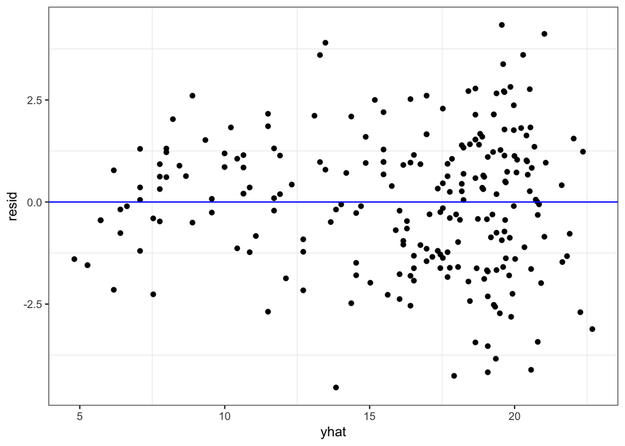

```r
resid <- resid(gls_var_fixed)
yhat <- fitted(gls_var_fixed)
final_residplot <- ggplot(data=pa, aes(x=yhat, y=resid))+
  geom_point()+
  geom_hline(yintercept=0, color = "blue")+
  theme_bw()+
  theme(panel.grid.major=element_blank())
print(final_residplot)
```

## Predicted vs observed data

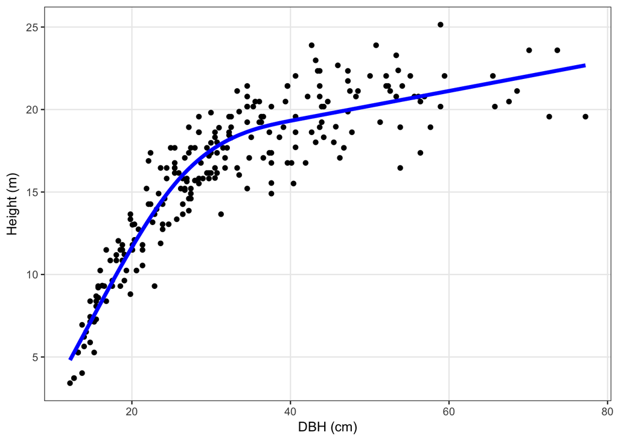

```r
modelplot <- ggplot(data=pa, aes(x=dbh.cm, y=ht.m))+
  geom_point()+
  geom_line(aes(y=gls_var_fixed$fitted, x=dbh.cm), color="blue", size=1.5)+
  theme_bw()+
  theme(panel.grid.minor=element_blank())+
  xlab("DBH (cm)")+
  ylab("Height (m)")

print(modelplot)
```

## Model Summary

The best model chosen to fit the data is a cubic splines generalized weighted least squares with the form of height ~ dbh and knots at 0.05, 0.35, and 0.75 with fixed weights of DBH.

```r
summary(gls_var_fixed)
```

```
## Generalized least squares fit by REML
##   Model: ht.m ~ dbh.cm + splinepoints_5
##   Data: NULL
##        AIC      BIC   logLik
##   942.2101 956.0142 -467.105
##
## Variance function:
##  Structure: fixed weights
##  Formula: ~dbh.cm
##
## Coefficients:
##                    Value Std.Error   t-value p-value
## (Intercept)    -6.073930 0.5461665 -11.12102       0
## dbh.cm          0.892888 0.0263689  33.86137       0
## splinepoints_5 -0.000929 0.0000435 -21.32301       0
##
##  Correlation:
##                (Intr) dbh.cm
## dbh.cm         -0.975
## splinepoints_5  0.884 -0.946
##
## Standardized residuals:
##         Min          Q1         Med          Q3         Max
## -3.13190156 -0.73436286  0.06490872  0.68748889  2.71966125
##
## Residual standard error: 0.3033536
## Degrees of freedom: 236 total; 233 residual
```